## Assignment 2: Network Safety

#### CSC 180 Intelligent Systems (Spring 2020)

# Helpful Functions for Tensorflow

```python
from collections.abc import Sequence
import matplotlib.pyplot as plt
import numpy as np
import pandas as pd
import shutil
import os
import tensorflow as tf
from tensorflow.keras.models import Sequential
from tensorflow.keras.layers import Dense, Activation, Dropout, Flatten
from tensorflow.keras.layers import Conv2D, MaxPooling2D
from tensorflow.keras.callbacks import EarlyStopping
from tensorflow.keras.callbacks import ModelCheckpoint
from sklearn import svm, datasets
from sklearn import metrics
from sklearn import preprocessing
from sklearn.preprocessing import OneHotEncoder
from sklearn.metrics import confusion_matrix, classification_report
from sklearn.model_selection import train_test_split
from sklearn.neighbors import KNeighborsClassifier
import random


# Encode text values to dummy variables(i.e. [1,0,0],[0,1,0],[0,0,1] for red,green,blue)
def encode_text_dummy(df, name):
    dummies = pd.get_dummies(df[name])
    for x in dummies.columns:
        dummy_name = "{}-{}".format(name, x)
        df[dummy_name] = dummies[x]
    df.drop(name, axis=1, inplace=True)


# Encode a numeric column as zscores
def encode_numeric_zscore(df, name, mean=None, sd=None):
    if mean is None:
        mean = df[name].mean()

    if sd is None:
        sd = df[name].std()

    df[name] = (df[name] - mean) / sd

def encode_text_index(df, name):
    le = preprocessing.LabelEncoder()
    df[name] = le.fit_transform(df[name])
    return le.classes_

# Convert all missing values in the specified column to the median
def missing_median(df, name):
    med = df[name].median()
    df[name] = df[name].fillna(med)


# Remove all rows where the specified column is +/- sd standard deviations
def remove_outliers(df, name, sd):
    drop_rows = df.index[(np.abs(df[name] - df[name].mean()) >= (sd * df[name].std()))]
    df.drop(drop_rows, axis=0, inplace=True)


%matplotlib inline
import matplotlib.pyplot as plt
from sklearn.metrics import roc_curve, auc

# Plot a confusion matrix.
# cm is the confusion matrix, names are the names of the classes.
def plot_confusion_matrix(cm, names, title='Confusion matrix', cmap=plt.cm.Blues):
    plt.imshow(cm, interpolation='nearest', cmap=cmap)
    plt.title(title)
    plt.colorbar()
    tick_marks = np.arange(len(names))
    plt.xticks(tick_marks, names, rotation=45)
    plt.yticks(tick_marks, names)
    plt.tight_layout()
    plt.ylabel('True label')
    plt.xlabel('Predicted label')


# Plot an ROC. pred - the predictions, y - the expected output.
def plot_roc(pred,y):
    fpr, tpr, thresholds = roc_curve(y, pred)
    roc_auc = auc(fpr, tpr)

    plt.figure()
    plt.plot(fpr, tpr, label='ROC curve (area = %0.2f)' % roc_auc)
    plt.plot([0, 1], [0, 1], 'k--')
    plt.xlim([0.0, 1.0])
    plt.ylim([0.0, 1.05])
    plt.xlabel('False Positive Rate')
    plt.ylabel('True Positive Rate')
    plt.title('Receiver Operating Characteristic (ROC)')
    plt.legend(loc="lower right")
    plt.show()
```

# Visualizing data

## Read data

```python
#define datatypes for readability later
datatype={}

datatype["duration"] = "continuous"
datatype["protocol_type"] = "symbolic"
datatype["service"] = "symbolic"
datatype["flag"] = "symbolic"
datatype["src_bytes"] = "continuous"
datatype["dst_bytes"] = "continuous"
datatype["land"] = "symbolic"
datatype["wrong_fragment"] = "continuous"
datatype["urgent"] = "continuous"
datatype["hot"] = "continuous"
datatype["num_failed_logins"] = "continuous"
datatype["logged_in"] = "symbolic"
datatype["num_compromised"] = "continuous"
datatype["root_shell"] = "continuous"
datatype["su_attempted"] = "continuous"
datatype["num_root"] = "continuous"
datatype["num_file_creations"] = "continuous"
datatype["num_shells"] = "continuous"
datatype["num_access_files"] = "continuous"
datatype["num_outbound_cmds"] = "continuous"
datatype["is_host_login"] = "symbolic"
datatype["is_guest_login"] = "symbolic"
datatype["count"] = "continuous"
datatype["srv_count"] = "continuous"
datatype["serror_rate"] = "continuous"
datatype["srv_serror_rate"] = "continuous"
datatype["rerror_rate"] = "continuous"
datatype["srv_rerror_rate"] = "continuous"
datatype["same_srv_rate"] = "continuous"
datatype["diff_srv_rate"] = "continuous"
datatype["srv_diff_host_rate"] = "continuous"
datatype["dst_host_count"] = "continuous"
datatype["dst_host_srv_count"] = "continuous"
datatype["dst_host_same_srv_rate"] = "continuous"
datatype["dst_host_diff_srv_rate"] = "continuous"
datatype["dst_host_same_src_port_rate"] = "continuous"
datatype["dst_host_srv_diff_host_rate"] = "continuous"
datatype["dst_host_serror_rate"] = "continuous"
datatype["dst_host_srv_serror_rate"] = "continuous"
datatype["dst_host_rerror_rate"] = "continuous"
datatype["dst_host_srv_rerror_rate"] = "continuous"
datatype["outcome"] = "symbolic"


df = pd.read_csv("network_intrusion_data.csv")

#assign columns
df.columns = ['duration','protocol_type','service','flag','src_bytes','dst_bytes','land','wrong_fragment','urgent','hot','num_failed_logins','logged_in','num_compromised','root_shell','su_attempted','num_root','num_file_creations','num_shells','num_access_files','num_outbound_cmds','is_host_login','is_guest_login','count','srv_count','serror_rate','srv_serror_rate','rerror_rate','srv_rerror_rate','same_srv_rate','diff_srv_rate','srv_diff_host_rate','dst_host_count','dst_host_srv_count','dst_host_same_srv_rate','dst_host_diff_srv_rate','dst_host_same_src_port_rate','dst_host_srv_diff_host_rate','dst_host_serror_rate','dst_host_srv_serror_rate','dst_host_rerror_rate','dst_host_srv_rerror_rate','outcome']

df
```

|  | duration | protocol_type | service | flag | src_bytes | dst_bytes | land | wrong_fragment | urgent | hot | ... | dst_host_srv_count | dst_host_same_srv_rate | dst_host_diff_srv_rate | dst_host_same_src_port_rate | dst_host_srv_diff_host_rate | dst_host_serror_rate | dst_host_srv_serror_rate | dst_host_rerror_rate | dst_host_srv_rerror_rate | outcome |
| --- | --- | --- | --- | --- | --- | --- | --- | --- | --- | --- | --- | --- | --- | --- | --- | --- | --- | --- | --- | --- | --- |
| 0 | 0 | tcp | http | SF | 239 | 486 | 0 | 0 | 0 | 0 | ... | 19 | 1.0 | 0.0 | 0.05 | 0.00 | 0.00 | 0.00 | 0.0 | 0.0 | normal. |
| 1 | 0 | tcp | http | SF | 235 | 1337 | 0 | 0 | 0 | 0 | ... | 29 | 1.0 | 0.0 | 0.03 | 0.00 | 0.00 | 0.00 | 0.0 | 0.0 | normal. |
| 2 | 0 | tcp | http | SF | 219 | 1337 | 0 | 0 | 0 | 0 | ... | 39 | 1.0 | 0.0 | 0.03 | 0.00 | 0.00 | 0.00 | 0.0 | 0.0 | normal. |
| 3 | 0 | tcp | http | SF | 217 | 2032 | 0 | 0 | 0 | 0 | ... | 49 | 1.0 | 0.0 | 0.02 | 0.00 | 0.00 | 0.00 | 0.0 | 0.0 | normal. |
| 4 | 0 | tcp | http | SF | 217 | 2032 | 0 | 0 | 0 | 0 | ... | 59 | 1.0 | 0.0 | 0.02 | 0.00 | 0.00 | 0.00 | 0.0 | 0.0 | normal. |
| ... | ... | ... | ... | ... | ... | ... | ... | ... | ... | ... | ... | ... | ... | ... | ... | ... | ... | ... | ... | ... | ... |
| 494015 | 0 | tcp | http | SF | 310 | 1881 | 0 | 0 | 0 | 0 | ... | 255 | 1.0 | 0.0 | 0.01 | 0.05 | 0.00 | 0.01 | 0.0 | 0.0 | normal. |
| 494016 | 0 | tcp | http | SF | 282 | 2286 | 0 | 0 | 0 | 0 | ... | 255 | 1.0 | 0.0 | 0.17 | 0.05 | 0.00 | 0.01 | 0.0 | 0.0 | normal. |
| 494017 | 0 | tcp | http | SF | 203 | 1200 | 0 | 0 | 0 | 0 | ... | 255 | 1.0 | 0.0 | 0.06 | 0.05 | 0.06 | 0.01 | 0.0 | 0.0 | normal. |
| 494018 | 0 | tcp | http | SF | 291 | 1200 | 0 | 0 | 0 | 0 | ... | 255 | 1.0 | 0.0 | 0.04 | 0.05 | 0.04 | 0.01 | 0.0 | 0.0 | normal. |
| 494019 | 0 | tcp | http | SF | 219 | 1234 | 0 | 0 | 0 | 0 | ... | 255 | 1.0 | 0.0 | 0.17 | 0.05 | 0.00 | 0.01 | 0.0 | 0.0 | normal. |

494020 rows × 42 columns

# Data Examination

Now we clean the data. Part of this process is checking for redundant records and records with missing values. Like normal, we will encode categorical data and normalizing numerical data.

First we want to search for duplicates and remove them. Then we want to see what kind of sample sizes we can work with which each of these, so instead of just returning each list I want to produce a count.

```python
df_dupes=df[df.duplicated()]
print ("Removing ",df_dupes.shape[0]," duplicate entries...")
df_unique=df.drop_duplicates()

#view all values
for (colName, colData) in df_unique.iteritems():
    valueCount=colData.drop_duplicates()
    print(colName, "-",valueCount.size, valueCount.values)

#check values count
i=0
for (colName, colData) in df_unique.iteritems():
    value_counts=colData.value_counts();
    print("Name: ",colName," Type: ",list(datatype)[i], "Size:", value_counts.size)
    print(value_counts.sort_values(ascending=False))
    print()
    i=i+1
```

```
Removing  348435  duplicate entries...
duration - 2495 [   0    1   79 ... 2695 2751  120]
protocol_type - 3 ['tcp' 'udp' 'icmp']
service - 66 ['http' 'smtp' 'finger' 'domain_u' 'auth' 'telnet' 'ftp' 'eco_i' 'ntp_u'
 'ecr_i' 'other' 'private' 'pop_3' 'ftp_data' 'rje' 'time' 'mtp' 'link'
 'remote_job' 'gopher' 'ssh' 'name' 'whois' 'domain' 'login' 'imap4'
 'daytime' 'ctf' 'nntp' 'shell' 'IRC' 'nnsp' 'http_443' 'exec' 'printer'
 'efs' 'courier' 'uucp' 'klogin' 'kshell' 'echo' 'discard' 'systat'
 'supdup' 'iso_tsap' 'hostnames' 'csnet_ns' 'pop_2' 'sunrpc' 'uucp_path'
 'netbios_ns' 'netbios_ssn' 'netbios_dgm' 'sql_net' 'vmnet' 'bgp' 'Z39_50'
 'ldap' 'netstat' 'urh_i' 'X11' 'urp_i' 'pm_dump' 'tftp_u' 'tim_i' 'red_i']
flag - 11 ['SF' 'S1' 'REJ' 'S2' 'S0' 'S3' 'RSTO' 'RSTR' 'RSTOS0' 'OTH' 'SH']
src_bytes - 3300 [239 235 219 ... 500 484 475]
dst_bytes - 10725 [  486  1337  2032 ... 34557 10592 13828]
land - 2 [0 1]
wrong_fragment - 3 [0 1 3]
urgent - 4 [0 2 1 3]
hot - 22 [ 0  1  3 19  6  4 30 24 14 18  2  5 17 22  7 16 12 20 10 28 15  9]
num_failed_logins - 6 [0 1 5 2 4 3]
logged_in - 2 [1 0]
num_compromised - 23 [  0   2   1   4  16   3 767   7  22  21 238   6 281   5  11 275  12  18
  38  13 884   9 102]
root_shell - 2 [0 1]
su_attempted - 3 [0 1 2]
num_root - 20 [  0   2   1   3   9   5   6  16   4 857  39  12 268 278   7  14 306  54
 993 119]
num_file_creations - 18 [ 0  1  2  4 15  9 16 28 10 21 14  5  7  8 12 25 22 20]
num_shells - 3 [0 2 1]
num_access_files - 7 [0 1 2 4 6 3 8]
num_outbound_cmds - 1 [0]
is_host_login - 1 [0]
is_guest_login - 2 [0 1]
count - 490 [  8   6   1   5  18  11   4   2  12   7  17   3  13  23  28  10   9  19
  16  27  14  15  22  20  26  36  21  31  24  37  34  32  29  39  25  35
  30  33  41  38  45  55  51  61  43  40  65  75  44  54  64  74  42  52
  62  72  50  60  70  80  49  59  69  79  46  56  66  76  48  47  57 316
 511 510 509 330 334 351 359 383 394 421 424 428  67 444 461 462 465 470
 471  95  96 100 489 491 497 498 508 154 172 182 189 205 225 232 233 237
 301 312 314  73  53  63  85  71  81  82  84  58  68  78  77  83  86  87
  88  89  90  91  92  93  94  97  98  99 108 118 128 138 148 158 168 103
```

[output cut: 779 more lines]

```
pod.                  206
nmap.                 158
guess_passwd.          53
buffer_overflow.       30
warezmaster.           20
land.                  19
imap.                  12
rootkit.               10
loadmodule.             9
ftp_write.              8
multihop.               7
phf.                    4
perl.                   3
spy.                    2
Name: outcome, dtype: int64
```

All this data looks valid.

`num_outbound_cmds` and `is_host_login` both have only 1 entry type, so they can be dropped.

We also see that several of the fields have a huge disparity in volume. `urgent` is almost entirely 0. Several other fields have a huge majority of one field with other fields being rare. However, several of these may be crucial for finding attacks.

`wrong_fragment`, `num_failed_logins`, `num_compromised`, `hot`, `root_shell`, `su_attempted`, `num_root`, `num_file_creations`, `num_shells`, `is_guest_login`, `num_access_files`

## Separating attacks from normal

We will filter off the attacks from the normal dataspace to see if their representation makes more sense when looking at non-normal data.

```python
#drop worthless data
df_unique=df_unique.drop(['is_host_login','num_outbound_cmds'], axis=1)

#remove rows with missing data
df_unique=df_unique.dropna()

outliers=['outcome','land','wrong_fragment', 'num_failed_logins', 'num_compromised', 'hot', 'root_shell', 'su_attempted', 'num_root', 'num_file_creations', 'num_shells', 'is_guest_login', 'num_access_files']
df_normals=df_unique[df_unique['outcome']=='normal.']
df_attacks=df_unique.drop(df_normals.index)

i=0
for (colName, colData) in df_attacks.iteritems():
    if(colName in outliers):
        value_counts=colData.value_counts();
        print("Name: ",colName," Type: ",list(datatype)[i], "Size:", value_counts.size)
        print(value_counts.sort_values(ascending=False))
        print()
    i=i+1
```

```
Name:  land  Type:  land Size: 2
0    57735
1       19
Name: land, dtype: int64

Name:  wrong_fragment  Type:  wrong_fragment Size: 3
0    56633
3      910
1      211
Name: wrong_fragment, dtype: int64

Name:  hot  Type:  hot Size: 14
0     56339
2       917
28      274
1       133
3        34
5        16
4        15
20        9
6         8
19        5
7         1
10        1
15        1
18        1
Name: hot, dtype: int64

Name:  num_failed_logins  Type:  num_failed_logins Size: 3
0    57701
1       52
5        1
Name: num_failed_logins, dtype: int64

Name:  num_compromised  Type:  num_compromised Size: 10
0     56832
1       901
2         8
4         7
3         1
```

[output cut: 64 more lines]

```
pod.                  206
nmap.                 158
guess_passwd.          53
buffer_overflow.       30
warezmaster.           20
land.                  19
imap.                  12
rootkit.               10
loadmodule.             9
ftp_write.              8
multihop.               7
phf.                    4
perl.                   3
spy.                    2
Name: outcome, dtype: int64
```

Surprisingly a lot of these values are still disproportionate even among errors only. Many of them will get dropped later.

`num_failed_logins`,`root_shell`,`su_attempted`,`num_root`, `num_file_creations`,`num_shells`, `num_access_files` seem irrelevent and have very little data to go off of.

## Data prep

Next I'm going to format the arrays in a useful way. To encode output as safe/unsafe, I will add another layer "attack" and drop the layer "outcome" (I supsect the neural network will rely too heavily on it if I leave it in.)

I am also going to apply **downsampling** here so that the quantity of good connections more closely matches the volume of attacks.

### Normalization and one-hot encoding

For `outcome` we don't care what the error code is (just that it is not normal), thus we went to one-hot encode for 2 values - normal and attack. After normalization columns may get dropped because the values are not significant enough to be nonzero. This is fine.

```python
drop_columns=['urgent','land','num_failed_logins', 'root_shell', 'su_attempted', 'num_root', 'num_file_creations',
              'num_shells', 'num_access_files']
#Model using fewer of the good samples - same number as most common error
df_downsampled=df_normals.sample(51820).append(df_attacks)
#model dropping rows that might be irrelevent
df_slim=df_unique.drop(drop_columns,axis=1)
#model dropping irrelevent rows AND using downsampling
df_slim_downsampled=df_downsampled.drop(drop_columns,axis=1)
#use 10% of data for model
df_sample=df_slim_downsampled.sample(frac=0.1)


#map for encoding
def make_binary(string):
    if(string=="normal."):
        return 0
    else:
        return 1

#encode y
y=df_sample["outcome"].map(make_binary)
#y_test_model=df_slim["outcome"].map(make_binary)
print(y)

y_one_hot = tf.keras.utils.to_categorical(y, 2)

print(y_one_hot)
#get arrays for training

x=df_sample.drop(["outcome"], axis=1)


#prep for model
for (name,column) in x.iteritems():
    if(datatype[name]=='continuous'):
        encode_numeric_zscore(x, name)
    else:
        encode_text_dummy(x,name)

 # Split into train/test
x_train, x_test, y_train, y_test = train_test_split(x, y, test_size=0.25, random_state=42)
```

```
374814    1
470680    1
87189     0
351432    1
139112    0
         ..
149827    1
345762    0
392561    1
357134    1
375330    1
Name: outcome, Length: 10957, dtype: int64
[[0. 1.]
 [0. 1.]
 [1. 0.]
 ...
 [0. 1.]
 [0. 1.]
 [0. 1.]]
```

After data prep some colums may now have no different values in them, in essence the rare values to a general majority may have been entirely dropped so the one-hot encoded label is now empty.

## Model training and testing

> Debugging by hand is like trying to find tiny holes in a dartboard covered in cloth...and you only have 5 darts.

To compare models, we are comparing the **accuracy, recall, precision** and **F1** score. For each type of model we will test different variable weights.

## Fully connected Neural Network

- Activation: **relu**, **sigmoid**, **tanh**
- **Layer count**
- **Neuron count**
- Optimizer: **Adam**, **SGC**

```python
def test_model(y_test, pred):
    pred = np.argmax(pred,axis=1)
    print(pred)
    y_true = np.argmax(y_test,axis=1)
    print(pred)
    cm = confusion_matrix(y_test, pred)
    print(cm)


    labels=["good","attack"]
    plt.figure()
    plot_confusion_matrix(cm, labels)
    plt.show()


    print(classification_report(y_test, pred))
    plot_roc(pred,y_test)
```

```python
def test_nn(activation, num_layers, num_neurons, optimizer, x_train,y_train,x_test,y_test):
    print("Fully connected neural network")
    print("Activation:",activation,"Number of layers: ",num_layers+2,"Number of neurons:",num_neurons,"Optimizer:",optimizer)

   # Build network
    model = Sequential()
    model.add(Dense(num_neurons, input_dim=x_train.shape[1], activation=activation))
    #model.add(Dense(num_neurons, input_dim=2, activation=activation))
    current=num_neurons
    interval=num_neurons/(num_layers+1)
    for i in range(num_layers):
        current=current-interval
        model.add(Dense(current, activation=activation))

    model.add(Dense(y_train.size, activation='softmax'))

    model.compile(loss='sparse_categorical_crossentropy', optimizer=optimizer)
    monitor = EarlyStopping(monitor='val_loss', min_delta=1e-3, patience=2, verbose=2, mode='auto')
    model.fit(x_train, y_train, validation_data=(x_test,y_test), callbacks=[monitor], verbose=2, epochs=1000)

    #test model
    pred = model.predict(x_test)
    print(pred)
    test_model(y_test, pred)

    return model
```

```
Fully connected neural network
Activation: relu Number of layers:  3 Number of neurons: 100 Optimizer: adam
WARNING:tensorflow:Falling back from v2 loop because of error: Failed to find data adapter that can handle input: <class 'pandas.core.frame.DataFrame'>, <class 'NoneType'>
Train on 8217 samples, validate on 2740 samples
8217/8217 - 3s - loss: 1.2489 - val_loss: 0.0327
8217/8217 - 3s - loss: 0.0241 - val_loss: 0.0265
8217/8217 - 2s - loss: 0.0202 - val_loss: 0.0205
8217/8217 - 3s - loss: 0.0188 - val_loss: 0.0198
8217/8217 - 3s - loss: 0.0146 - val_loss: 0.0196
Epoch 00005: early stopping
WARNING:tensorflow:Falling back from v2 loop because of error: Failed to find data adapter that can handle input: <class 'pandas.core.frame.DataFrame'>, <class 'NoneType'>
[[9.99898195e-01 1.00596582e-04 2.06797524e-10 ... 3.68704983e-10
  1.88826801e-10 1.14049034e-10]
 [9.76892233e-01 2.31024176e-02 9.53828794e-10 ... 1.86337146e-09
  7.84246446e-10 4.83403595e-10]
 [1.01722571e-05 9.99989867e-01 2.31270103e-12 ... 5.05963804e-12
  2.14293709e-12 1.37181998e-12]
 ...
 [9.99899864e-01 9.92161877e-05 1.56099828e-10 ... 2.82887852e-10
  1.43048656e-10 8.52922663e-11]
 [6.52452436e-05 9.99933600e-01 1.54513471e-10 ... 2.95569430e-10
  1.45328971e-10 9.65009878e-11]
 [2.99874537e-05 9.99969959e-01 2.43539425e-11 ... 4.88665636e-11
  2.29348606e-11 1.49180234e-11]]
[0 0 1 ... 0 1 1]
[0 0 1 ... 0 1 1]
[[1301    4]
 [   8 1427]]
```

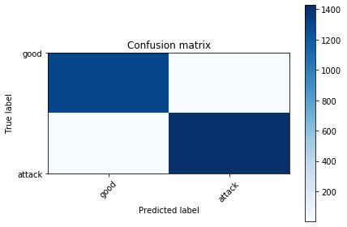

```
              precision    recall  f1-score   support

           0       0.99      1.00      1.00      1305
           1       1.00      0.99      1.00      1435

    accuracy                           1.00      2740
   macro avg       1.00      1.00      1.00      2740
weighted avg       1.00      1.00      1.00      2740
```

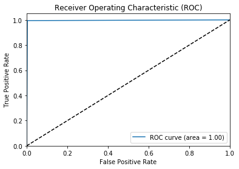

```
<tensorflow.python.keras.engine.sequential.Sequential at 0x1960cae0ac8>
```

```python
test_nn('relu',1,100,'adam',x_train,y_train,x_test,y_test)
```

```
Fully connected neural network
Activation: relu Number of layers:  3 Number of neurons: 100 Optimizer: adam
WARNING:tensorflow:Falling back from v2 loop because of error: Failed to find data adapter that can handle input: <class 'pandas.core.frame.DataFrame'>, <class 'NoneType'>
Train on 8217 samples, validate on 2740 samples
8217/8217 - 3s - loss: 1.2479 - val_loss: 0.0294
8217/8217 - 3s - loss: 0.0251 - val_loss: 0.0211
8217/8217 - 3s - loss: 0.0197 - val_loss: 0.0199
8217/8217 - 3s - loss: 0.0172 - val_loss: 0.0197
8217/8217 - 3s - loss: 0.0150 - val_loss: 0.0185
8217/8217 - 3s - loss: 0.0140 - val_loss: 0.0194
8217/8217 - 3s - loss: 0.0130 - val_loss: 0.0173
8217/8217 - 3s - loss: 0.0119 - val_loss: 0.0168
8217/8217 - 3s - loss: 0.0127 - val_loss: 0.0159
8217/8217 - 3s - loss: 0.0096 - val_loss: 0.0145
8217/8217 - 3s - loss: 0.0096 - val_loss: 0.0137
8217/8217 - 2s - loss: 0.0084 - val_loss: 0.0146
Epoch 00012: early stopping
WARNING:tensorflow:Falling back from v2 loop because of error: Failed to find data adapter that can handle input: <class 'pandas.core.frame.DataFrame'>, <class 'NoneType'>
[[9.9968791e-01 3.1199169e-04 2.0789913e-11 ... 2.8758541e-11
  2.3988906e-11 2.9075180e-11]
 [9.8280752e-01 1.7163781e-02 4.1701202e-09 ... 5.4469087e-09
  4.0424437e-09 4.7230500e-09]
 [3.5263947e-09 1.0000000e+00 2.3517062e-14 ... 1.8474431e-14
  1.4705436e-14 1.0395347e-14]
 ...
 [9.9948043e-01 5.1952514e-04 1.9481401e-11 ... 2.6688830e-11
  2.2060841e-11 2.7428778e-11]
 [2.4909971e-08 1.0000000e+00 3.5558354e-13 ... 2.9752310e-13
  2.4143377e-13 1.7081730e-13]
 [2.5544994e-08 1.0000000e+00 3.7058429e-13 ... 2.9788536e-13
  2.4509084e-13 1.7177132e-13]]
[0 0 1 ... 0 1 1]
[0 0 1 ... 0 1 1]
[[1301    4]
 [   6 1429]]
```

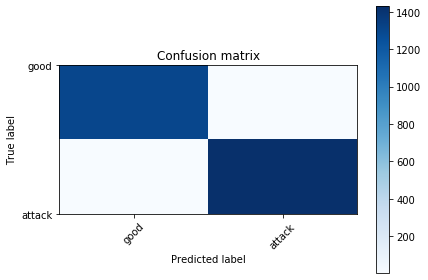

```
              precision    recall  f1-score   support

           0       1.00      1.00      1.00      1305
           1       1.00      1.00      1.00      1435

    accuracy                           1.00      2740
   macro avg       1.00      1.00      1.00      2740
weighted avg       1.00      1.00      1.00      2740
```

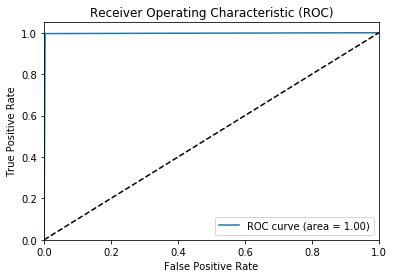

```
Fully connected neural network
Activation: sigmoid Number of layers:  3 Number of neurons: 100 Optimizer: adam
WARNING:tensorflow:Falling back from v2 loop because of error: Failed to find data adapter that can handle input: <class 'pandas.core.frame.DataFrame'>, <class 'NoneType'>
Train on 8217 samples, validate on 2740 samples
8217/8217 - 3s - loss: 2.1637 - val_loss: 0.7182
8217/8217 - 2s - loss: 0.7060 - val_loss: 0.7029
8217/8217 - 3s - loss: 0.6944 - val_loss: 0.6623
8217/8217 - 2s - loss: 0.4862 - val_loss: 0.2822
8217/8217 - 2s - loss: 0.1677 - val_loss: 0.1188
8217/8217 - 2s - loss: 0.0813 - val_loss: 0.0547
8217/8217 - 2s - loss: 0.0437 - val_loss: 0.0383
8217/8217 - 3s - loss: 0.0328 - val_loss: 0.0323
8217/8217 - 3s - loss: 0.0271 - val_loss: 0.0300
8217/8217 - 3s - loss: 0.0237 - val_loss: 0.0269
8217/8217 - 2s - loss: 0.0213 - val_loss: 0.0241
8217/8217 - 2s - loss: 0.0196 - val_loss: 0.0238
8217/8217 - 3s - loss: 0.0180 - val_loss: 0.0230
8217/8217 - 3s - loss: 0.0171 - val_loss: 0.0222
8217/8217 - 3s - loss: 0.0161 - val_loss: 0.0234
Epoch 00015: early stopping
WARNING:tensorflow:Falling back from v2 loop because of error: Failed to find data adapter that can handle input: <class 'pandas.core.frame.DataFrame'>, <class 'NoneType'>
[[9.96210456e-01 3.19940830e-03 6.42036326e-08 ... 6.12134272e-08
  6.74846845e-08 6.94343072e-08]
 [9.92474616e-01 6.83790911e-03 7.69872486e-08 ... 7.28532257e-08
  8.12815557e-08 8.36551308e-08]
 [2.04572664e-03 9.97855723e-01 1.32243798e-08 ... 1.19454073e-08
  1.40377852e-08 1.53517021e-08]
 ...
 [9.96247232e-01 3.16362921e-03 6.41109210e-08 ... 6.11342443e-08
  6.73775915e-08 6.93265108e-08]
 [2.05874862e-03 9.97844219e-01 1.30334650e-08 ... 1.17750245e-08
  1.38390348e-08 1.51283182e-08]
 [2.05519143e-03 9.97847319e-01 1.30845175e-08 ... 1.18209442e-08
  1.38918903e-08 1.51880961e-08]]
[0 0 1 ... 0 1 1]
[0 0 1 ... 0 1 1]
[[1303    2]
 [   9 1426]]
```

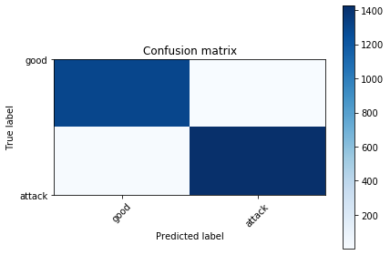

```
              precision    recall  f1-score   support

           0       0.99      1.00      1.00      1305
           1       1.00      0.99      1.00      1435

    accuracy                           1.00      2740
   macro avg       1.00      1.00      1.00      2740
weighted avg       1.00      1.00      1.00      2740
```

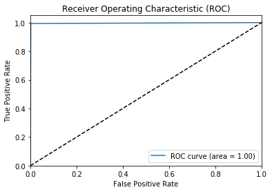

```
Fully connected neural network
Activation: tanh Number of layers:  3 Number of neurons: 100 Optimizer: adam
WARNING:tensorflow:Falling back from v2 loop because of error: Failed to find data adapter that can handle input: <class 'pandas.core.frame.DataFrame'>, <class 'NoneType'>
Train on 8217 samples, validate on 2740 samples
8217/8217 - 3s - loss: 2.1397 - val_loss: 0.1177
8217/8217 - 3s - loss: 0.0567 - val_loss: 0.0378
8217/8217 - 3s - loss: 0.0285 - val_loss: 0.0286
8217/8217 - 3s - loss: 0.0209 - val_loss: 0.0286
8217/8217 - 3s - loss: 0.0171 - val_loss: 0.0243
8217/8217 - 3s - loss: 0.0149 - val_loss: 0.0218
8217/8217 - 3s - loss: 0.0132 - val_loss: 0.0221
8217/8217 - 3s - loss: 0.0124 - val_loss: 0.0203
8217/8217 - 3s - loss: 0.0114 - val_loss: 0.0223
8217/8217 - 3s - loss: 0.0105 - val_loss: 0.0211
Epoch 00010: early stopping
WARNING:tensorflow:Falling back from v2 loop because of error: Failed to find data adapter that can handle input: <class 'pandas.core.frame.DataFrame'>, <class 'NoneType'>
[[9.9882537e-01 3.8361346e-04 8.6765581e-08 ... 9.5186699e-08
  9.4770584e-08 8.8298847e-08]
 [9.9416804e-01 4.0520737e-03 2.0248717e-07 ... 2.2179943e-07
  2.1397720e-07 1.9803475e-07]
 [6.3589665e-05 9.9919981e-01 8.0678362e-08 ... 8.6754412e-08
  8.6983391e-08 8.3361059e-08]
 ...
 [9.9880815e-01 3.9646434e-04 8.7328743e-08 ... 9.5871791e-08
  9.5591695e-08 8.8813159e-08]
 [6.3805142e-05 9.9920183e-01 8.0400170e-08 ... 8.6454605e-08
  8.6683130e-08 8.3063171e-08]
 [6.4222877e-05 9.9919301e-01 8.1511040e-08 ... 8.7634092e-08
  8.7858858e-08 8.4195406e-08]]
[0 0 1 ... 0 1 1]
[0 0 1 ... 0 1 1]
[[1301    4]
 [   8 1427]]
```

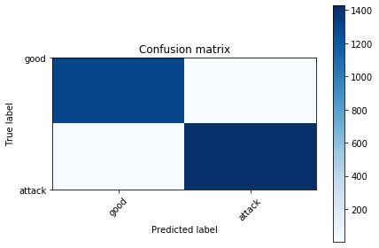

```
              precision    recall  f1-score   support

           0       0.99      1.00      1.00      1305
           1       1.00      0.99      1.00      1435

    accuracy                           1.00      2740
   macro avg       1.00      1.00      1.00      2740
weighted avg       1.00      1.00      1.00      2740
```

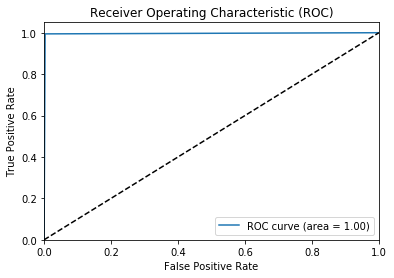

```
Fully connected neural network
Activation: relu Number of layers:  3 Number of neurons: 100 Optimizer: sgd
WARNING:tensorflow:Falling back from v2 loop because of error: Failed to find data adapter that can handle input: <class 'pandas.core.frame.DataFrame'>, <class 'NoneType'>
Train on 8217 samples, validate on 2740 samples
8217/8217 - 3s - loss: 2.4222 - val_loss: 0.1111
8217/8217 - 3s - loss: 0.0814 - val_loss: 0.0614
8217/8217 - 3s - loss: 0.0525 - val_loss: 0.0458
8217/8217 - 3s - loss: 0.0422 - val_loss: 0.0390
8217/8217 - 3s - loss: 0.0366 - val_loss: 0.0349
8217/8217 - 3s - loss: 0.0333 - val_loss: 0.0323
8217/8217 - 3s - loss: 0.0314 - val_loss: 0.0304
8217/8217 - 3s - loss: 0.0293 - val_loss: 0.0291
8217/8217 - 3s - loss: 0.0281 - val_loss: 0.0283
8217/8217 - 3s - loss: 0.0269 - val_loss: 0.0274
8217/8217 - 3s - loss: 0.0260 - val_loss: 0.0268
8217/8217 - 3s - loss: 0.0248 - val_loss: 0.0271
Epoch 00012: early stopping
WARNING:tensorflow:Falling back from v2 loop because of error: Failed to find data adapter that can handle input: <class 'pandas.core.frame.DataFrame'>, <class 'NoneType'>
[[9.9905652e-01 9.2775834e-04 2.3518743e-09 ... 2.3929971e-09
  2.7446998e-09 2.4023035e-09]
 [8.4025156e-01 1.5972865e-01 3.2548111e-09 ... 3.1867111e-09
  4.3285526e-09 3.3389500e-09]
 [1.1290538e-05 9.9997866e-01 1.3352501e-09 ... 1.6283398e-09
  1.7784727e-09 1.0498004e-09]
 ...
 [9.9903995e-01 9.4752823e-04 1.8912023e-09 ... 1.9146746e-09
  2.2253737e-09 1.9125430e-09]
 [1.4975763e-04 9.9966681e-01 2.4803407e-08 ... 2.9937063e-08
  3.1472304e-08 2.0501110e-08]
 [2.6868656e-05 9.9993551e-01 5.0559845e-09 ... 6.1069456e-09
  6.6264354e-09 4.0590424e-09]]
[0 0 1 ... 0 1 1]
[0 0 1 ... 0 1 1]
[[1293   12]
 [   9 1426]]
```

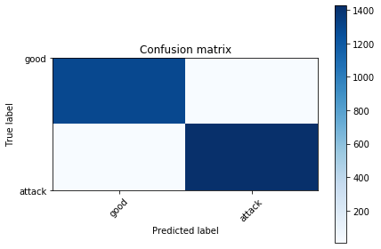

```
              precision    recall  f1-score   support

           0       0.99      0.99      0.99      1305
           1       0.99      0.99      0.99      1435

    accuracy                           0.99      2740
   macro avg       0.99      0.99      0.99      2740
weighted avg       0.99      0.99      0.99      2740
```

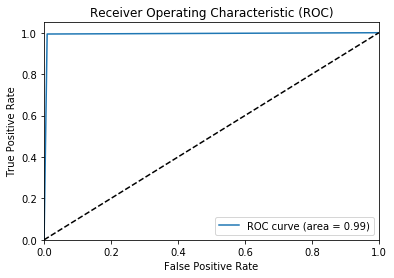

```
Fully connected neural network
Activation: sigmoid Number of layers:  3 Number of neurons: 100 Optimizer: sgd
WARNING:tensorflow:Falling back from v2 loop because of error: Failed to find data adapter that can handle input: <class 'pandas.core.frame.DataFrame'>, <class 'NoneType'>
Train on 8217 samples, validate on 2740 samples
8217/8217 - 3s - loss: 2.2993 - val_loss: 0.7127
8217/8217 - 3s - loss: 0.6826 - val_loss: 0.6605
8217/8217 - 3s - loss: 0.6299 - val_loss: 0.5940
8217/8217 - 3s - loss: 0.5419 - val_loss: 0.4783
8217/8217 - 3s - loss: 0.4019 - val_loss: 0.3251
8217/8217 - 3s - loss: 0.2683 - val_loss: 0.2204
8217/8217 - 3s - loss: 0.1909 - val_loss: 0.1692
8217/8217 - 3s - loss: 0.1526 - val_loss: 0.1428
8217/8217 - 3s - loss: 0.1312 - val_loss: 0.1270
8217/8217 - 3s - loss: 0.1173 - val_loss: 0.1162
8217/8217 - 3s - loss: 0.1070 - val_loss: 0.1085
8217/8217 - 3s - loss: 0.0991 - val_loss: 0.1003
8217/8217 - 3s - loss: 0.0923 - val_loss: 0.0941
8217/8217 - 3s - loss: 0.0866 - val_loss: 0.0887
8217/8217 - 3s - loss: 0.0816 - val_loss: 0.0837
8217/8217 - 2s - loss: 0.0772 - val_loss: 0.0790
8217/8217 - 2s - loss: 0.0734 - val_loss: 0.0747
8217/8217 - 2s - loss: 0.0699 - val_loss: 0.0714
8217/8217 - 2s - loss: 0.0668 - val_loss: 0.0673
8217/8217 - 2s - loss: 0.0640 - val_loss: 0.0643
8217/8217 - 2s - loss: 0.0614 - val_loss: 0.0614
8217/8217 - 2s - loss: 0.0591 - val_loss: 0.0589
8217/8217 - 2s - loss: 0.0570 - val_loss: 0.0567
8217/8217 - 2s - loss: 0.0552 - val_loss: 0.0546
8217/8217 - 2s - loss: 0.0535 - val_loss: 0.0531
8217/8217 - 2s - loss: 0.0521 - val_loss: 0.0513
8217/8217 - 2s - loss: 0.0507 - val_loss: 0.0499
8217/8217 - 2s - loss: 0.0494 - val_loss: 0.0487
8217/8217 - 2s - loss: 0.0482 - val_loss: 0.0473
8217/8217 - 2s - loss: 0.0472 - val_loss: 0.0463
8217/8217 - 2s - loss: 0.0463 - val_loss: 0.0452
8217/8217 - 2s - loss: 0.0453 - val_loss: 0.0443
8217/8217 - 2s - loss: 0.0444 - val_loss: 0.0435
8217/8217 - 2s - loss: 0.0435 - val_loss: 0.0428
8217/8217 - 2s - loss: 0.0428 - val_loss: 0.0420
8217/8217 - 2s - loss: 0.0421 - val_loss: 0.0412
```

[output cut: 11 more lines]

```
 [9.72042918e-01 2.69815736e-02 1.26247699e-07 ... 1.29736648e-07
  1.24337362e-07 1.08833774e-07]
 [4.23921098e-04 9.99416947e-01 2.19053025e-08 ... 2.42549127e-08
  2.24737580e-08 2.07045048e-08]
 ...
 [9.97313797e-01 2.39550974e-03 4.31796074e-08 ... 4.41325625e-08
  4.25191615e-08 3.67861794e-08]
 [1.23061310e-03 9.98511732e-01 3.56569956e-08 ... 3.92479969e-08
  3.65227741e-08 3.34879644e-08]
 [6.74713170e-04 9.99123991e-01 2.77767125e-08 ... 3.06767198e-08
  2.84653723e-08 2.61908379e-08]]
[0 0 1 ... 0 1 1]
[0 0 1 ... 0 1 1]
[[1299    6]
 [  25 1410]]
```

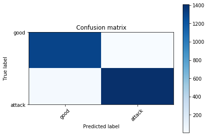

```
              precision    recall  f1-score   support

           0       0.98      1.00      0.99      1305
           1       1.00      0.98      0.99      1435

    accuracy                           0.99      2740
   macro avg       0.99      0.99      0.99      2740
weighted avg       0.99      0.99      0.99      2740
```

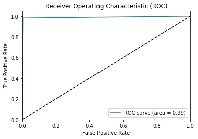

```
Fully connected neural network
Activation: tanh Number of layers:  3 Number of neurons: 100 Optimizer: sgd
WARNING:tensorflow:Falling back from v2 loop because of error: Failed to find data adapter that can handle input: <class 'pandas.core.frame.DataFrame'>, <class 'NoneType'>
Train on 8217 samples, validate on 2740 samples
8217/8217 - 3s - loss: 3.3486 - val_loss: 0.6034
8217/8217 - 3s - loss: 0.4444 - val_loss: 0.4137
8217/8217 - 2s - loss: 0.3119 - val_loss: 0.3462
8217/8217 - 2s - loss: 0.2115 - val_loss: 0.1579
8217/8217 - 2s - loss: 0.1027 - val_loss: 0.0820
8217/8217 - 2s - loss: 0.0651 - val_loss: 0.0603
8217/8217 - 2s - loss: 0.0502 - val_loss: 0.0497
8217/8217 - 2s - loss: 0.0417 - val_loss: 0.0437
8217/8217 - 2s - loss: 0.0363 - val_loss: 0.0397
8217/8217 - 3s - loss: 0.0326 - val_loss: 0.0368
8217/8217 - 3s - loss: 0.0297 - val_loss: 0.0356
8217/8217 - 3s - loss: 0.0281 - val_loss: 0.0334
8217/8217 - 2s - loss: 0.0264 - val_loss: 0.0326
8217/8217 - 3s - loss: 0.0252 - val_loss: 0.0312
8217/8217 - 3s - loss: 0.0242 - val_loss: 0.0307
8217/8217 - 3s - loss: 0.0231 - val_loss: 0.0298
8217/8217 - 3s - loss: 0.0225 - val_loss: 0.0295
8217/8217 - 3s - loss: 0.0219 - val_loss: 0.0285
8217/8217 - 2s - loss: 0.0212 - val_loss: 0.0282
8217/8217 - 3s - loss: 0.0208 - val_loss: 0.0276
Epoch 00020: early stopping
WARNING:tensorflow:Falling back from v2 loop because of error: Failed to find data adapter that can handle input: <class 'pandas.core.frame.DataFrame'>, <class 'NoneType'>
[[9.99464095e-01 4.45633714e-06 5.61248896e-08 ... 7.42750146e-08
  6.30663379e-08 6.72762965e-08]
 [9.71486628e-01 2.13617496e-02 8.03992236e-07 ... 1.06762343e-06
  8.93976392e-07 9.44042654e-07]
 [1.31423743e-11 9.99424338e-01 6.49967191e-08 ... 6.27414494e-08
  7.04419350e-08 6.64492887e-08]
 ...
 [9.99572814e-01 2.78729067e-06 5.02041964e-08 ... 6.57849455e-08
  5.60056606e-08 6.01008949e-08]
 [2.86978896e-11 9.99642372e-01 4.81805884e-08 ... 4.78916142e-08
  5.28777839e-08 5.03303212e-08]
 [2.55039288e-11 9.99011040e-01 1.19170416e-07 ... 1.14025624e-07
  1.28349498e-07 1.21483993e-07]]
[0 0 1 ... 0 1 1]
[0 0 1 ... 0 1 1]
[[1296    9]
 [   8 1427]]
```

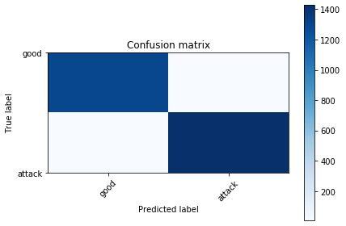

```
              precision    recall  f1-score   support

           0       0.99      0.99      0.99      1305
           1       0.99      0.99      0.99      1435

    accuracy                           0.99      2740
   macro avg       0.99      0.99      0.99      2740
weighted avg       0.99      0.99      0.99      2740
```

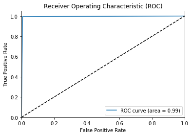

```
Fully connected neural network
Activation: relu Number of layers:  4 Number of neurons: 100 Optimizer: adam
WARNING:tensorflow:Falling back from v2 loop because of error: Failed to find data adapter that can handle input: <class 'pandas.core.frame.DataFrame'>, <class 'NoneType'>
Train on 8217 samples, validate on 2740 samples
8217/8217 - 3s - loss: 1.2874 - val_loss: 0.0257
8217/8217 - 2s - loss: 0.0226 - val_loss: 0.0198
8217/8217 - 2s - loss: 0.0229 - val_loss: 0.0226
8217/8217 - 2s - loss: 0.0175 - val_loss: 0.0189
Epoch 00004: early stopping
WARNING:tensorflow:Falling back from v2 loop because of error: Failed to find data adapter that can handle input: <class 'pandas.core.frame.DataFrame'>, <class 'NoneType'>
[[9.9969220e-01 3.0785869e-04 1.9074041e-12 ... 3.3395947e-12
  2.0665143e-12 1.8462178e-12]
 [9.8761058e-01 1.2389431e-02 4.3784264e-12 ... 8.5230616e-12
  6.2609063e-12 4.6005049e-12]
 [3.8891885e-05 9.9996114e-01 2.3777178e-16 ... 8.1242636e-16
  1.0159601e-15 2.5143612e-16]
 ...
 [9.9965203e-01 3.4796342e-04 1.7017335e-12 ... 2.9953520e-12
  1.8656728e-12 1.6382836e-12]
 [1.7782430e-04 9.9982220e-01 2.1909314e-14 ... 6.3147851e-14
  7.7251214e-14 2.2872771e-14]
 [1.2395227e-04 9.9987602e-01 7.4156422e-15 ... 2.2326066e-14
  2.7711408e-14 7.9213598e-15]]
[0 0 1 ... 0 1 1]
[0 0 1 ... 0 1 1]
[[1303    2]
 [  10 1425]]
```

[46 more figures not shown]

```
<tensorflow.python.keras.engine.sequential.Sequential at 0x1961c8cec48>
```

```python
test_nn('relu',1,100,'adam',x_train,y_train,x_test,y_test)
test_nn('sigmoid',1,100,'adam',x_train,y_train,x_test,y_test)
test_nn('tanh',1,100,'adam',x_train,y_train,x_test,y_test)
#sgd
test_nn('relu',1,100,'sgd',x_train,y_train,x_test,y_test)
test_nn('sigmoid',1,100,'sgd',x_train,y_train,x_test,y_test)
test_nn('tanh',1,100,'sgd',x_train,y_train,x_test,y_test)
#layer count
test_nn('relu',2,100,'adam',x_train,y_train,x_test,y_test)
test_nn('sigmoid',2,100,'adam',x_train,y_train,x_test,y_test)
test_nn('tanh',2,100,'adam',x_train,y_train,x_test,y_test)
test_nn('relu',2,100,'sgd',x_train,y_train,x_test,y_test)
test_nn('sigmoid',2,100,'sgd',x_train,y_train,x_test,y_test)
test_nn('tanh',2,100,'sgd',x_train,y_train,x_test,y_test)
test_nn('relu',3,100,'adam',x_train,y_train,x_test,y_test)
test_nn('sigmoid',3,100,'adam',x_train,y_train,x_test,y_test)
test_nn('tanh',3,100,'adam',x_train,y_train,x_test,y_test)
test_nn('relu',3,100,'sgd',x_train,y_train,x_test,y_test)
test_nn('sigmoid',3,100,'sgd',x_train,y_train,x_test,y_test)
test_nn('tanh',3,100,'sgd',x_train,y_train,x_test,y_test)
#neron count
test_nn('relu',2,50,'adam',x_train,y_train,x_test,y_test)
test_nn('sigmoid',2,50,'adam',x_train,y_train,x_test,y_test)
test_nn('tanh',2,50,'adam',x_train,y_train,x_test,y_test)
test_nn('relu',2,50,'sgd',x_train,y_train,x_test,y_test)
test_nn('sigmoid',2,50,'sgd',x_train,y_train,x_test,y_test)
test_nn('tanh',2,50,'sgd',x_train,y_train,x_test,y_test)
test_nn('relu',3,50,'adam',x_train,y_train,x_test,y_test)
test_nn('sigmoid',3,50,'adam',x_train,y_train,x_test,y_test)
test_nn('tanh',3,50,'adam',x_train,y_train,x_test,y_test)
test_nn('relu',3,50,'sgd',x_train,y_train,x_test,y_test)
test_nn('sigmoid',3,50,'sgd',x_train,y_train,x_test,y_test)
test_nn('tanh',3,50,'sgd',x_train,y_train,x_test,y_test)
test_nn('relu',2,250,'adam',x_train,y_train,x_test,y_test)
test_nn('sigmoid',2,250,'adam',x_train,y_train,x_test,y_test)
test_nn('tanh',2,250,'adam',x_train,y_train,x_test,y_test)
test_nn('relu',2,250,'sgd',x_train,y_train,x_test,y_test)
test_nn('sigmoid',2,250,'sgd',x_train,y_train,x_test,y_test)
test_nn('tanh',2,250,'sgd',x_train,y_train,x_test,y_test)
test_nn('relu',3,250,'adam',x_train,y_train,x_test,y_test)
test_nn('sigmoid',3,250,'adam',x_train,y_train,x_test,y_test)
test_nn('tanh',3,250,'adam',x_train,y_train,x_test,y_test)
test_nn('relu',3,250,'sgd',x_train,y_train,x_test,y_test)
test_nn('sigmoid',3,250,'sgd',x_train,y_train,x_test,y_test)
test_nn('tanh',3,250,'sgd',x_train,y_train,x_test,y_test)
```

## Convuluted Neural Network

```python
#prep data for cnn by treating as a 1 height image
img_data = x.values.reshape((x.shape[0], 1, x.shape[1], 1))
x_cnn_train, y_cnn_test, y_cnn_train, y_cnn_test = train_test_split(img_data, y_one_hot, test_size=0.25, random_state=42)

print(x_cnn_train.shape)
print(y_cnn_train.shape)
print(x_cnn_test.shape)
print(y_cnn_test.shape)

def test_cnn(activation, num_layers, num_neurons, optimizer, num_kernals, _kernal_size, x_train,y_train,x_test,y_test):
     # define a CNN
    cnn = Sequential()
    for i in range(num_kernals):
        cnn.add(Conv2D(64, kernel_size=_kernal_size, strides=(1, 1), activation=activation, input_shape=x_test.shape[1:]))
        #cnn.add(Conv2D(64, kernel_size=_kernal_size, strides=(1, 1), activation=activation, input_shape=x_test.shape))
        cnn.add(MaxPooling2D(pool_size=2))

    #change to 1D output
    cnn.add(Flatten())

    current=num_neurons
    interval=num_neurons/(num_layers+1)
    for i in range(num_layers):
        current=current-interval
        cnn.add(Dense(current, activation=activation))
        cnn.add(Dropout(0.5))
    cnn.add(Dense(3, activation="softmax"))

    # define optimizer and objective, compile cnn

    cnn.compile(loss="categorical_crossentropy", optimizer=optimizer)
    monitor = EarlyStopping(monitor='val_loss', min_delta=1e-3, patience=2, verbose=2, mode='auto')
    cnn.fit(x_train, y_train, validation_data=(x_test,y_test), callbacks=[monitor], verbose=2, epochs=1000)


    #test model
    pred = model.predict(x_test)
    test_model(y_test, pred)
    return model
```

[output not shown]

```python
def test_cnn(activation, num_layers, num_neurons, optimizer, num_kernals, _kernal_size, x_train,y_train,x_test,y_test):
    print("Convoluted neural network")
    print("Activation:",activation,"Number of layers: ",num_layers+2,"Number of neurons:",num_neurons,"Optimizer:",optimizer)

   # Build network
    model = Sequential()
    for i in range(num_kernals):
        model.add(Conv2D(64, kernel_size=_kernal_size, strides=(1, 1), activation=activation, input_shape=x_test.shape[1:]))
        #cnn.add(Conv2D(64, kernel_size=_kernal_size, strides=(1, 1), activation=activation, input_shape=x_test.shape))
        model.add(MaxPooling2D(pool_size=2))


    #change to 1D output
    cnn.add(Flatten())


    model.add(Dense(num_neurons, input_dim=x_train.shape[1], activation=activation))
    #model.add(Dense(num_neurons, input_dim=2, activation=activation))
    current=num_neurons
    interval=num_neurons/(num_layers+1)
    for i in range(num_layers):
        current=current-interval
        model.add(Dense(current, activation=activation))

    model.add(Dense(y_train.size, activation='softmax'))

    model.compile(loss='sparse_categorical_crossentropy', optimizer=optimizer)
    monitor = EarlyStopping(monitor='val_loss', min_delta=1e-3, patience=2, verbose=2, mode='auto')
    #model.fit(x_train, y_train, validation_data=(x_test,y_test), callbacks=[monitor], verbose=2, epochs=1000)

    #test model
    pred = model.predict(x_test)
    print(pred)
    test_model(y_test, pred)
```

```python
cnn = Sequential()
cnn.add(Conv2D(64, kernel_size=(1, 3), strides=(1, 1),
                 activation='relu',
                 input_shape=(x_cnn_train.shape[1:])))

# the above code is equivalent to
# model.add(Conv1D(64, kernel_size=3, strides=1, activation='relu', input_shape=(128, 1)))

cnn.add(MaxPooling2D(pool_size=(1,2)))

cnn.add(Conv2D(128, kernel_size=(1, 3), strides=(1, 1),
                 activation='relu',
                 input_shape=(x_cnn_train.shape[1:])))
cnn.add(MaxPooling2D(pool_size=(1,2)))


cnn.add(Flatten())
cnn.add(Dense(1024, activation="relu"))
cnn.add(Dropout(0.5))
cnn.add(Dense(3, activation="softmax"))

# define optimizer and objective, compile cnn

cnn.compile(loss="sparse_categorical_crossentropy", optimizer="adam")
#monitor = EarlyStopping(monitor='val_loss', min_delta=1e-3, patience=2, verbose=2, mode='auto')
#cnn.fit(x_train, y_train, validation_data=(x_test,y_test), callbacks=[monitor], verbose=2, epochs=1000)
cnn.fit(x_cnn_train, y_cnn_train, validation_data=(x_cnn_test,y_cnn_test), verbose=2, epochs=10)


pred = cnn.predict(x_cnn_test)

test_model(y_cnn_test, pred)
```

```
Train on 8217 samples, validate on 2740 samples
```

[output not shown]

[output cut: 38 more lines]

[output not shown]

```python
np.argmax(pred, axis=1)
score = metrics.accuracy_score(y_test, pred)
print('Accuracy: {}'.format(score))


f1 = metrics.f1_score(y_test, pred, average='weighted')
print('Averaged F1: {}'.format(f1))


print(metrics.classification_report(y_test, pred))
```

[output not shown]

```python
test_cnn('relu',1,100,'adam',2,3,x_cnn_train,y_cnn_train,x_cnn_test,y_cnn_test)
```

```
Convoluted neural network
Activation: relu Number of layers:  3 Number of neurons: 100 Optimizer: adam
```

[output not shown]

[output cut: 66 more lines]

[output not shown]